# Algoritma Linear Regression dengan R

Fachri Putra S - Institut Teknologi Statistika dan Bisnis Muhammadiyah

2023-01-12

# Algoritma Linear Regression

Linear Regression adalah model statistik yang menguji hubungan linear anatara dua variabel atau lebih. Variabel-variabel tersebut dikenal dengan istilah variabel terikat (dependent variable) dan variabel bebas (independent variable). Dimana:

Dependent Variable adalah faktor utama yang ingin kita prediksi; target variable (numeric) Independent Variable adalah faktor-faktor yang kita hipotesa memiliki pengaruh terhadap target variable; predictor variable (numerical/categorical) Hubungan linier pada dasarnya berarti bahwa ketika satu (atau lebih) variabel independen meningkat (atau menurun), variabel dependen meningkat (atau menurun) juga.

# Tahapan Algoritma Linear Regression

# Eksperimen

## Import Library

Pada Learning By Building: Linear Regression kita akan menggunakan beberapa library yang memiliki fungsi masing-masing, library yang digunakan antara lain :

```r
library(dplyr)
library(GGally)
library(MLmetrics)
library(performance)
library(lmtest)
library(car)
library(stringr)
```

## Import Dataset

Dataset yang digunakan adalah abalone.csv untuk mengimpor dataset tersebut kita akan menggunakan fungsi read.csv() dan akan disimpan ke dalam variabel abalone:

```r
abalone <- read.csv("D:/Documents/abalone.csv")
```

```r
head(abalone)
```

```
##   Sex Length Diameter Height Whole.weight Shucked.weight Viscera.weight
## 1   M  0.455    0.365  0.095       0.5140         0.2245         0.1010
## 2   M  0.350    0.265  0.090       0.2255         0.0995         0.0485
## 3   F  0.530    0.420  0.135       0.6770         0.2565         0.1415
## 4   M  0.440    0.365  0.125       0.5160         0.2155         0.1140
## 5   I  0.330    0.255  0.080       0.2050         0.0895         0.0395
## 6   I  0.425    0.300  0.095       0.3515         0.1410         0.0775
##   Shell.weight Rings
## 1        0.150    15
## 2        0.070     7
## 3        0.210     9
## 4        0.155    10
## 5        0.055     7
## 6        0.120     8
```

## Exploratory Data Analysis

Exploratory Data Analysis Data abalone merupakan data hasil observarsi pengukuran fisik dari abalone. Untuk mengetahui jumlah baris dan kolom kita akan menggunakan fungsi dim():

```r
dim(abalone)
```

```
## [1] 4177    9
```

Data abalone memiliki 4177 baris dan 9 kolom Selanjutnya kita akan melakukan pengecekan missing values kita dapat menggunakan kombinasi fungsi colSums() dan is.na()

```r
colSums(is.na(abalone))
```

```
##            Sex         Length       Diameter         Height   Whole.weight
##              0              0              0              0              0
## Shucked.weight Viscera.weight   Shell.weight          Rings
##              0              0              0              0
```

## Cross-Validation

Kita akan menggunakan fungsi RNGkind() dan set.seed() untuk menghasilkan kombinasi angka random yang akan mengontrol saat dilakukannya splitting data.

```r
RNGkind(sample.kind = 'Rounding')
set.seed(666)
```

Selanjutnya kita akan membagi data kita dengan ratio 80:20, fungsi yang digunakan adalah sample() yang akan di assign ke variabel index. Nantinya variabel index akan digunakan untuk subsetting pada data abalone

```r
index <- sample(nrow(abalone), size = nrow(abalone)*0.8)

abalone_train <- abalone[index,]
abalone_test <- abalone[-index,]
```

## Create model

```r
model_abalone_all <- lm(Rings ~ ., abalone_train)
```

Salah satu metric untuk melihat performa atau evaluasi dari suatu model multiple linear regression menggunakan nilai adj r-squared yang bisa di dapatkan dari hasil fungsi summary().

```r
summary(model_abalone_all)
```

```
##
## Call:
## lm(formula = Rings ~ ., data = abalone_train)
##
## Residuals:
##      Min       1Q   Median       3Q      Max
## -10.0777  -1.3127  -0.3669   0.8767  11.5993
##
## Coefficients:
##                 Estimate Std. Error t value Pr(>|t|)
## (Intercept)      3.85046    0.32249  11.940  < 2e-16 ***
## SexI            -0.77701    0.11497  -6.758 1.64e-11 ***
## SexM             0.07084    0.09347   0.758 0.448603
## Length           0.40615    2.08453   0.195 0.845528
## Diameter         9.92890    2.56229   3.875 0.000109 ***
## Height          10.45725    1.60536   6.514 8.42e-11 ***
## Whole.weight     9.45351    0.82231  11.496  < 2e-16 ***
## Shucked.weight -20.64807    0.92742 -22.264  < 2e-16 ***
## Viscera.weight -10.15860    1.46125  -6.952 4.31e-12 ***
## Shell.weight     8.38301    1.29771   6.460 1.20e-10 ***
## ---
## Signif. codes:  0 '***' 0.001 '**' 0.01 '*' 0.05 '.' 0.1 ' ' 1
##
## Residual standard error: 2.199 on 3331 degrees of freedom
## Multiple R-squared:  0.5378, Adjusted R-squared:  0.5366
## F-statistic: 430.7 on 9 and 3331 DF,  p-value: < 2.2e-16
```

## Tuning Model (Stepwise)

fungsi yang digunakan adalah step(). Kita akan menggunakan model_abalone_all sebagai object, dengan parameter direction ‘backward’.

```r
model_abalone_backward <- step(object = model_abalone_all,
                             direction = 'backward',
                             trace = 0)
```

kita dapat melihat hasil model_abalone_backward menggunakan fungsi summary()

```r
summary(model_abalone_backward)
```

```
##
## Call:
## lm(formula = Rings ~ Sex + Diameter + Height + Whole.weight +
##     Shucked.weight + Viscera.weight + Shell.weight, data = abalone_train)
##
## Residuals:
##      Min       1Q   Median       3Q      Max
## -10.0908  -1.3143  -0.3628   0.8805  11.5916
##
## Coefficients:
##                 Estimate Std. Error t value Pr(>|t|)
## (Intercept)      3.87099    0.30474  12.702  < 2e-16 ***
## SexI            -0.77543    0.11467  -6.762 1.60e-11 ***
## SexM             0.07116    0.09345   0.761    0.446
## Diameter        10.38078    1.08915   9.531  < 2e-16 ***
## Height          10.46786    1.60421   6.525 7.82e-11 ***
## Whole.weight     9.45137    0.82211  11.496  < 2e-16 ***
## Shucked.weight -20.63667    0.92544 -22.299  < 2e-16 ***
## Viscera.weight -10.12601    1.45143  -6.977 3.63e-12 ***
## Shell.weight     8.37357    1.29661   6.458 1.21e-10 ***
## ---
## Signif. codes:  0 '***' 0.001 '**' 0.01 '*' 0.05 '.' 0.1 ' ' 1
##
## Residual standard error: 2.199 on 3332 degrees of freedom
## Multiple R-squared:  0.5378, Adjusted R-squared:  0.5367
## F-statistic: 484.6 on 8 and 3332 DF,  p-value: < 2.2e-16
```

Untuk melakukan prediksi sebuah data kita akan menggunakan fungsi predict()

```r
pred_abalone_all <- predict(
  object = model_abalone_all,
  newdata = abalone_test,
  interval = 'prediction',
  level = 0.95
)

head(pred_abalone_all)
```

```
##          fit      lwr      upr
## 1   9.178634 4.863419 13.49385
## 12  9.409793 5.094541 13.72505
## 14 10.430987 6.116246 14.74573
## 15 10.381523 6.064783 14.69826
## 17  8.234053 3.919309 12.54880
## 18  9.038411 4.723073 13.35375
```

```r
pred_abalone_backward <- predict(
  object = model_abalone_backward,
  newdata = abalone_test,
  interval = 'prediction',
  level = 0.95
)

head(pred_abalone_backward)
```

```
##          fit      lwr      upr
## 1   9.183962 4.869704 13.49822
## 12  9.417727 5.103836 13.73162
## 14 10.424051 6.110497 14.73761
## 15 10.374405 6.058883 14.68993
## 17  8.240069 3.926372 12.55377
## 18  9.037718 4.723009 13.35243
```

## Mean Absolute Percentage Error (MAPE)

MAPE menunjukkan seberapa besar penyimpangannya dalam bentuk persentase. Untuk melakukan perhitungan error tersebut kita akan menggunakan fungsi MAPE()

```r
MAPE(y_pred = pred_abalone_all, y_true = abalone_test$Rings)
```

```
## [1] 0.3696868
```

```r
MAPE(y_pred = pred_abalone_backward, y_true = abalone_test$Rings)
```

```
## [1] 0.3695736
```

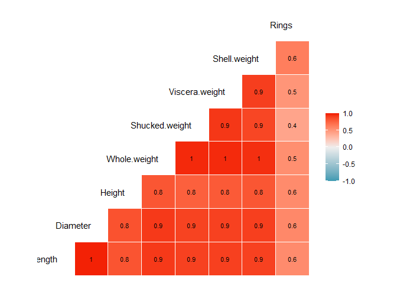

```r
ggcorr(abalone, label= T, label_size = 3, hjust = 1)
```